# Aaron’s Week 6 Update

Aaron Swoboda

2025-05-07

# Load some data

```r
# emissions data
emissionsSince1750 <- read_sheet("https://docs.google.com/spreadsheets/d/15gnvwp5HWqPVb4_hODz6j1DlLiaQvnAao6cIxokcf8g/edit?usp=sharing", skip = 1)
```

```
## ✔ Reading from "ECON269-Emissions-data".
```

```
## ✔ Range '2:10000000'.
```

```r
names(emissionsSince1750) <- c("year", "EmissionsMMTC")
```

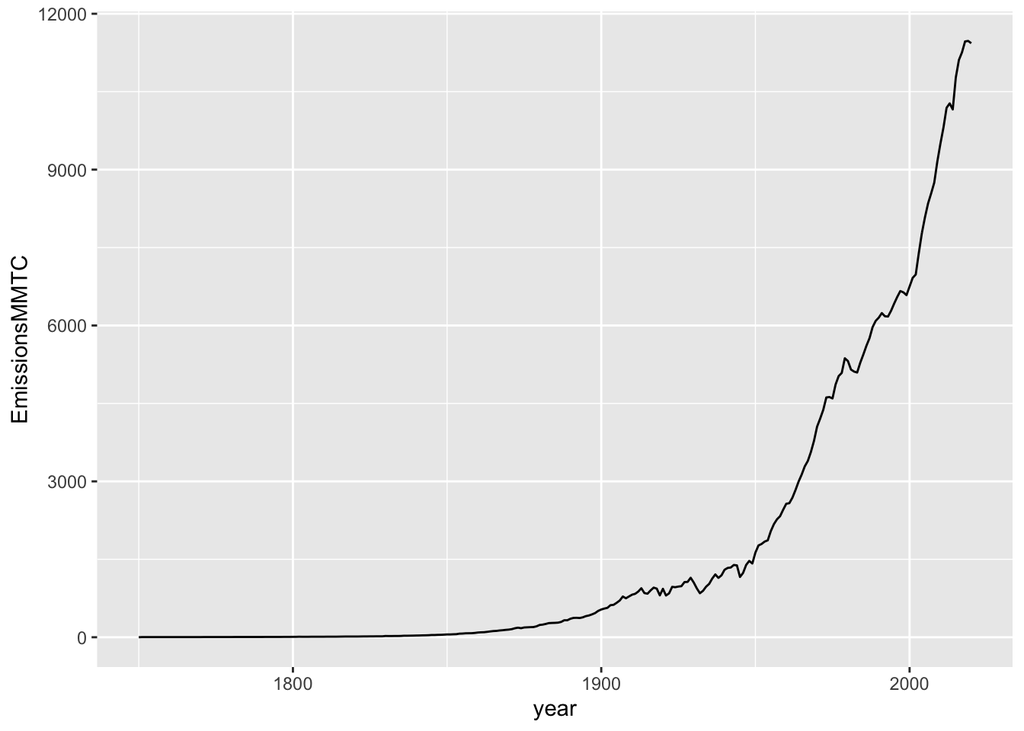

```r
emissionsSince1750 %>%
  ggplot(aes(year, EmissionsMMTC)) +
  geom_line()
```

## Climate Module (Lab 1)

### Emissions to CO2

Five Box model of carbon dioxide concentrations. Each box follows equation 13.1:
$$CO2_{i, t} =
(1-CO2decay)*CO2_{i, t-1} + CO2convert*CO2share_i*CO2emissions_{t-1}$$

```r
CO2difference <- function(CO2previous, newCO2emissions) {
  CO2decay <- c(0, 1-exp(-1/363), 1-exp(-1/74), 1-exp(-1/17), 1-exp(-1/2))
  CO2share <- c(0.13, 0.20, 0.32, 0.25, 0.10);
  CO2convert <- 1/2.13/1000;

  CO2concnew = (1-CO2decay)*CO2previous + CO2convert*CO2share*newCO2emissions # Equation 13.1
  CO2concnew
}

StartYear <- 1750
EndYear <- 2020

HistoricData <- emissionsSince1750[1:(EndYear - StartYear + 1), ]
HistoricData$Box1 <- 0
HistoricData$Box2 <- 0
HistoricData$Box3 <- 0
HistoricData$Box4 <- 0
HistoricData$Box5 <- 0

HistoricData$Box1[1] <- 275
Box1col <- which(colnames(HistoricData) == "Box1")

for (i in 2:(EndYear - StartYear + 1)) {
 HistoricData[i, Box1col:(Box1col+4)] <- CO2difference(HistoricData[i - 1, Box1col:(Box1col+4)],
                                                       HistoricData$EmissionsMMTC[i - 1])
}

HistoricData$CO2conc <- HistoricData$Box1 + HistoricData$Box2 + HistoricData$Box3 +
  HistoricData$Box4 + HistoricData$Box5
```

We can plot the CO2 concentration over time.

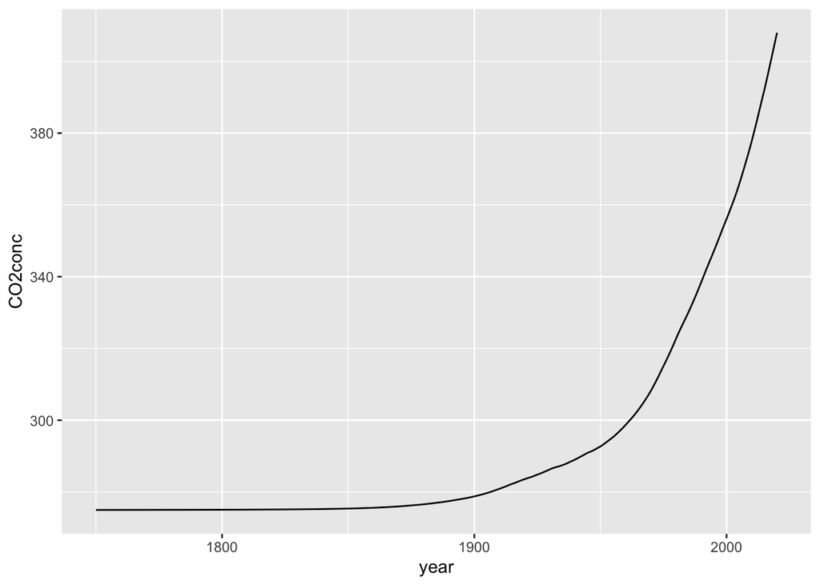

```r
HistoricData %>%
  ggplot(aes(x = year, y = CO2conc)) +
  geom_line()
```

### CO2 concentrations to Temperatures

Radiative Forcing (Equation 13.3) and Temperature anomalies (Equations 13.4 and 13.5)

```r
RadForc <-function(CO2) {
  5.35*log(CO2/275);
}

Temps <- function(atmtempold, oceantempold, radforc) {
  par1 <- 1.15
  par2 <- 0.0256
  par3 <- 0.00738
  par4 <- 0.00568

  atmtempnew   = atmtempold   +
      par2*(par1*radforc-atmtempold) +
      par3*(oceantempold-atmtempold)

  oceantempnew = oceantempold +
    par4*(atmtempold-oceantempold)

  temps <- c(atmtempnew, oceantempnew)
  names(temps) <- c("atm", "ocean")
  temps
}
```

```r
HistoricData$RF <- RadForc(HistoricData$CO2conc)

HistoricData$TempAtm = 0
HistoricData$TempOcean = 0

StartYear <- 1850
EndYear <- 2020

for (i in (which(HistoricData$year == StartYear)+1):which(HistoricData$year == EndYear)) {
  temp <- Temps(HistoricData$TempAtm[i-1], HistoricData$TempOcean[i-1], HistoricData$RF[i])
  HistoricData$TempAtm[i] <- temp["atm"]
  HistoricData$TempOcean[i] <- temp["ocean"]
}
```

We can now plot temp over time

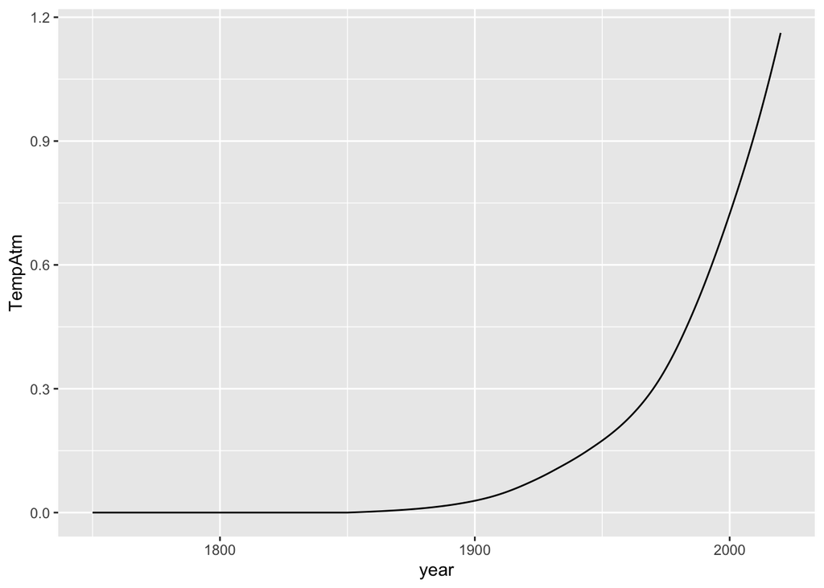

```r
HistoricData %>%
  ggplot(aes(year, TempAtm)) +
  geom_line()
```

# Future Scenario Example: Constant Emissions

```r
years <- 2020:2300

Scenario1 <- HistoricData[which(HistoricData$year == 2020), ]
Scenario1[2:length(years), ] <- 0

Scenario1$year <- years
Scenario1$EmissionsMMTC = Scenario1$EmissionsMMTC[1]

#Implement Five box model for CO2 concentrations
for (i in 2:length(Scenario1$EmissionsMMTC)) {
 Scenario1[i, Box1col:(Box1col+4)] <- CO2difference(Scenario1[i - 1, Box1col:(Box1col+4)],
                                                       Scenario1$EmissionsMMTC[i - 1])
 }
# Calculate total CO2 concentration in atmosphere
Scenario1$CO2conc <- Scenario1$Box1 + Scenario1$Box2 + Scenario1$Box3 +
  Scenario1$Box4 + Scenario1$Box5
# Calculate radiative forcing
Scenario1$RF <- RadForc(Scenario1$CO2conc)
# Calculate Temperatures
for (i in 2:length(Scenario1$EmissionsMMTC)) {
    temp <- Temps(Scenario1$TempAtm[i-1], Scenario1$TempOcean[i-1], Scenario1$RF[i])
  Scenario1$TempAtm[i] <- temp["atm"]
  Scenario1$TempOcean[i] <- temp["ocean"]
}
```

# Economic Module

Let’s use the global data as an example.

```r
# global kaya data
global.df <- read_sheet("https://docs.google.com/spreadsheets/d/1SBco_xnwTeglMsO8X_h9JDGQ3SgUVd1tTLBt0ZtHqZ8/edit?gid=0#gid=0")
```

```
## ✔ Reading from "Kaya Identity Data".
```

```
## ✔ Range 'Sheet1'.
```

```r
names(global.df)
```

```
## [1] "Year"       "Emissions"  "Population" "GDP"        "Energy"
```

### Population

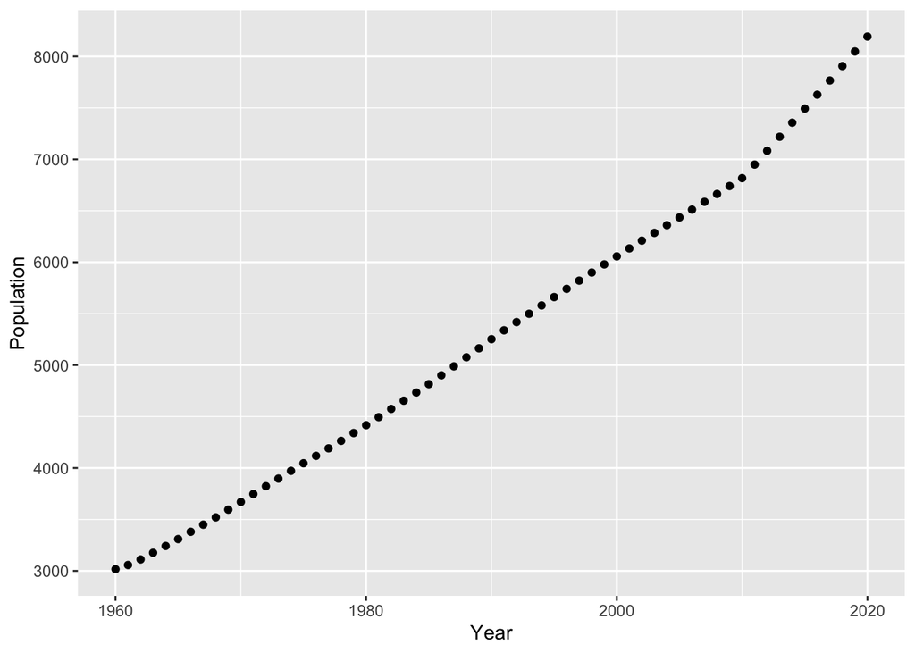

```r
global.df %>%
  ggplot(aes(Year, Population)) +
  geom_point()
```

```r
global.df$Population[which(global.df$Year == 2020)]/global.df$Population[which(global.df$Year == 2019)]-1
```

```
## [1] 0.0180169
```

```r
round(global.df$Population[2:61]/global.df$Population[1:60]-1 , 3)
```

```
##  [1] 0.014 0.018 0.021 0.021 0.021 0.021 0.020 0.021 0.021 0.021 0.021 0.020
## [13] 0.019 0.019 0.019 0.018 0.018 0.017 0.018 0.018 0.018 0.018 0.017 0.017
## [25] 0.017 0.018 0.018 0.018 0.017 0.017 0.016 0.015 0.015 0.015 0.015 0.014
## [37] 0.014 0.014 0.013 0.013 0.013 0.012 0.012 0.012 0.012 0.012 0.012 0.012
## [49] 0.012 0.011 0.019 0.019 0.019 0.019 0.019 0.018 0.018 0.018 0.018 0.018
```

```r
PopulationModel = data.frame(Year = 2020:2300,
                             Population = global.df$Population[which(global.df$Year == 2020)],
                             GrowthRate =  global.df$Population[which(global.df$Year == 2020)]/global.df$Population[which(global.df$Year == 2019)]-1)

PopulationModel[1, ]
```

```
##   Year Population GrowthRate
## 1 2020       8193  0.0180169
```

```r
for (i in 2:length(PopulationModel$Year)) {
  PopulationModel$GrowthRate[i] <- PopulationModel$GrowthRate[i-1]*.95
  PopulationModel$Population[i] <- PopulationModel$Population[i-1]*(1 + PopulationModel$GrowthRate[i])
}
```

### Energy Intensity

We need to calculate the energy intensity of GDP before we can model it in the future.

```r
global.df$EnergyIntensity <- global.df$Energy/global.df$GDP
```

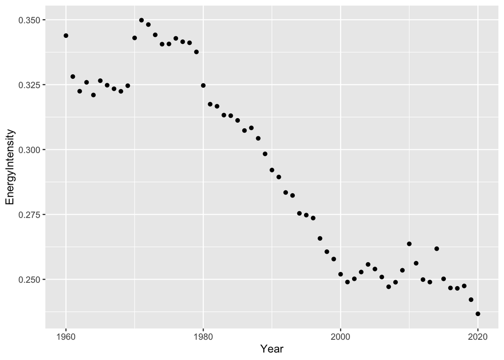

```r
global.df %>%
  ggplot(aes(Year, EnergyIntensity)) +
  geom_point()
```

```r
round(global.df$EnergyIntensity[2:61]/global.df$EnergyIntensity[1:60]-1 , 3)
```

```
##  [1] -0.046 -0.017  0.011 -0.015  0.017 -0.005 -0.004 -0.003  0.007  0.057
## [11]  0.020 -0.005 -0.011 -0.010  0.000  0.006 -0.004 -0.001 -0.010 -0.038
## [21] -0.022 -0.003 -0.011 -0.001 -0.006 -0.013  0.003 -0.013 -0.020 -0.021
## [31] -0.009 -0.021 -0.004 -0.024 -0.002 -0.004 -0.029 -0.019 -0.011 -0.023
## [41] -0.012  0.005  0.010  0.012 -0.007 -0.012 -0.015  0.007  0.019  0.040
## [51] -0.028 -0.025 -0.004  0.052 -0.044 -0.014 -0.001  0.004 -0.021 -0.023
```

```r
aveEnergyIntGrowth <- mean(global.df$EnergyIntensity[2:61]/global.df$EnergyIntensity[1:60]-1)
aveEnergyIntGrowth
```

```
## [1] -0.006028318
```

```r
EnergyIntensityModel = data.frame(Year = 2020:2300,
                             EnergyIntensity = global.df$EnergyIntensity[which(global.df$Year == 2020)],
                             GrowthRate =  aveEnergyIntGrowth)

EnergyIntensityModel[1, ]
```

```
##   Year EnergyIntensity   GrowthRate
## 1 2020       0.2367197 -0.006028318
```

```r
for (i in 2:length(EnergyIntensityModel$Year)) {
  EnergyIntensityModel$EnergyIntensity[i] <- EnergyIntensityModel$EnergyIntensity[i-1]*(1 + EnergyIntensityModel$GrowthRate[i])
}
```

### Emissions Intensity

We need to calculate the emissions intensity of ebnergy before we can model it in the future.

```r
global.df$EmissionsIntensity <- global.df$Emissions/global.df$Energy
```

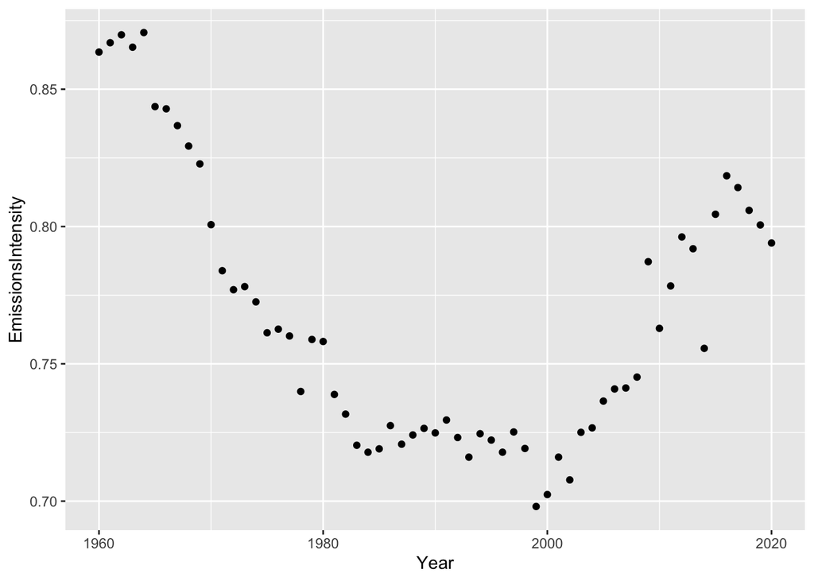

```r
global.df %>%
  ggplot(aes(Year, EmissionsIntensity)) +
  geom_point()
```

```r
round(global.df$EmissionsIntensity[2:61]/global.df$EmissionsIntensity[1:60]-1 , 3)
```

```
##  [1]  0.004  0.003 -0.005  0.006 -0.031 -0.001 -0.007 -0.009 -0.008 -0.027
## [11] -0.021 -0.009  0.001 -0.007 -0.015  0.002 -0.003 -0.027  0.026 -0.001
## [21] -0.025 -0.010 -0.015 -0.004  0.002  0.012 -0.009  0.005  0.003 -0.002
## [31]  0.006 -0.009 -0.010  0.012 -0.003 -0.006  0.010 -0.008 -0.029  0.006
## [41]  0.019 -0.012  0.024  0.002  0.013  0.006  0.000  0.005  0.056 -0.031
## [51]  0.020  0.023 -0.005 -0.046  0.065  0.017 -0.005 -0.010 -0.007 -0.008
```

```r
aveEmissionsIntGrowth <- mean(global.df$EmissionsIntensity[2:61]/global.df$EmissionsIntensity[1:60]-1)
aveEmissionsIntGrowth
```

```
## [1] -0.001232515
```

```r
EmissionsIntensityModel = data.frame(Year = 2020:2300,
                             EmissionsIntensity = global.df$EmissionsIntensity[which(global.df$Year == 2020)],
                             GrowthRate =  aveEmissionsIntGrowth)

EmissionsIntensityModel[1, ]
```

```
##   Year EmissionsIntensity   GrowthRate
## 1 2020          0.7939992 -0.001232515
```

```r
for (i in 2:length(EmissionsIntensityModel$Year)) {
  EmissionsIntensityModel$EmissionsIntensity[i] <- EmissionsIntensityModel$EmissionsIntensity[i-1]*(1 + EmissionsIntensityModel$GrowthRate[i])
}
```

### GDP

For GDP we will use the Cobb-Douglass Production function and the Solow Growth model.

$$GDP = A*K^\alpha*L^{(1-\alpha)}$$
where K is capital, L is labor, and A is the Total Factor Productivity.

```r
CobbDouglassGDP <- function(A, K, L, alpha = 0.2) {
  A*K^alpha*L^(1-alpha)
}
```

We are also told that capital also follows a difference equation, changing over time depending on depreciation, investment and savings.

$$K_t = K_{t-1} - \delta K_{t-1} +
Investment{t}$$

and because Investment = Savings, and we assume Savings is a constant share of output, $Savings = s*GDP$, then

$$K_t = K_{t-1} - \delta K_{t-1} +
s*GDP_{t-1}$$

```r
Kapital <- function(Kold, GDPold, d = 0.1, s = 0.1) {
  (1-d)*Kold + s*GDPold
}
```

Add some new columns to our data to use for calculations

```r
global.df$A = 1 # text says use 1 as a starter value
global.df$K = 0
global.df$GDPmodeled = 0

global.df$K[1] = (.1*global.df$A[1]/.1)^(1/(1-.2))*global.df$Population[1]
global.df$GDPmodeled[1] = CobbDouglassGDP(global.df$A[1], global.df$K[1], global.df$Population[1])

global.df[1, ]
```

```
## # A tibble: 1 × 10
##    Year Emissions Population   GDP Energy EnergyIntensity EmissionsIntensity
##   <dbl>     <dbl>      <dbl> <dbl>  <dbl>           <dbl>              <dbl>
## 1  1960      2569       3016  8651   2975           0.344              0.864
## # ℹ 3 more variables: A <dbl>, K <dbl>, GDPmodeled <dbl>
```

We see that the modeled GDP value is well below the actual GDP observed. We need to adjust our A value until the model is calibrated to yield the observed value. Note that when we adjust A, we also need to adjust our steady state capital value too.

```r
global.df$A = 2.323 # I tried various values until the modeled value was close to the actual value.
global.df$K = 0
global.df$GDPmodeled = 0

global.df$K[1] = (.1*global.df$A[1]/.1)^(1/(1-.2))*global.df$Population[1]
global.df$GDPmodeled[1] = CobbDouglassGDP(global.df$A[1], global.df$K[1], global.df$Population[1])

global.df[1, ]
```

```
## # A tibble: 1 × 10
##    Year Emissions Population   GDP Energy EnergyIntensity EmissionsIntensity
##   <dbl>     <dbl>      <dbl> <dbl>  <dbl>           <dbl>              <dbl>
## 1  1960      2569       3016  8651   2975           0.344              0.864
## # ℹ 3 more variables: A <dbl>, K <dbl>, GDPmodeled <dbl>
```

Now that we have a starting value for A and Capital, we can implement our capital difference equation and use the new Population variable to estimate GDP over time.

```r
for (i in 2:length(global.df$Year)) {
  global.df$K[i] = Kapital(global.df$K[i-1], global.df$GDPmodeled[i-1])
  global.df$GDPmodeled[i] = CobbDouglassGDP(global.df$A[i], global.df$K[i], global.df$Population[i])
}
global.df[which(global.df$Year == 2020), ]
```

```
## # A tibble: 1 × 10
##    Year Emissions Population   GDP Energy EnergyIntensity EmissionsIntensity
##   <dbl>     <dbl>      <dbl> <dbl>  <dbl>           <dbl>              <dbl>
## 1  2020     11432       8193 60823  14398           0.237              0.794
## # ℹ 3 more variables: A <dbl>, K <dbl>, GDPmodeled <dbl>
```

While the modeled GDP is larger than in 1960, it hasn’t grown as much as the observed GDP. We will now let A, Total Factor Productivity, also grow over time.

```r
TFPgrowth <- 0.02 # this 2% value is suggested by the text

for (i in 2:length(global.df$Year)) {
  global.df$A[i] = global.df$A[i-1]*(1+TFPgrowth)
  global.df$K[i] = Kapital(global.df$K[i-1], global.df$GDPmodeled[i-1])
  global.df$GDPmodeled[i] = CobbDouglassGDP(global.df$A[i], global.df$K[i], global.df$Population[i])
}
global.df[which(global.df$Year == 2020), ]
```

```
## # A tibble: 1 × 10
##    Year Emissions Population   GDP Energy EnergyIntensity EmissionsIntensity
##   <dbl>     <dbl>      <dbl> <dbl>  <dbl>           <dbl>              <dbl>
## 1  2020     11432       8193 60823  14398           0.237              0.794
## # ℹ 3 more variables: A <dbl>, K <dbl>, GDPmodeled <dbl>
```

Now modeled GDP is higher than observed, so it seems like TFP growth should be less than 0.02

```r
TFPgrowth <- 0.01375 # adjusted this value until the 2020 GDP and modeled GDP are similar in 2020

for (i in 2:length(global.df$Year)) {
  global.df$A[i] = global.df$A[i-1]*(1+TFPgrowth)
  global.df$K[i] = Kapital(global.df$K[i-1], global.df$GDPmodeled[i-1])
  global.df$GDPmodeled[i] = CobbDouglassGDP(global.df$A[i], global.df$K[i], global.df$Population[i])
}
global.df[which(global.df$Year == 2020), ]
```

```
## # A tibble: 1 × 10
##    Year Emissions Population   GDP Energy EnergyIntensity EmissionsIntensity
##   <dbl>     <dbl>      <dbl> <dbl>  <dbl>           <dbl>              <dbl>
## 1  2020     11432       8193 60823  14398           0.237              0.794
## # ℹ 3 more variables: A <dbl>, K <dbl>, GDPmodeled <dbl>
```

The text says to model future GDP assuming total factor productivity growth rate is 0.99 times the previous time period growth rate for Total Factor Productivity.

```r
GDPModel = PopulationModel
GDPModel$GrowthRate = 0.01375
GDPModel$A = global.df$A[which(global.df$Year == 2020)]
GDPModel$K = global.df$K[which(global.df$Year == 2020)]
GDPModel$GDPmodeled = global.df$GDPmodeled[which(global.df$Year == 2020)]

GDPModel[1, ]
```

```
##   Year Population GrowthRate      A        K GDPmodeled
## 1 2020       8193    0.01375 5.2711 45384.68   60818.75
```

```r
for (i in 2:length(GDPModel$Year)) {
  GDPModel$GrowthRate[i] = GDPModel$GrowthRate[i-1]*.99
  GDPModel$A[i] = GDPModel$A[i-1]*(1 + GDPModel$GrowthRate[i])
  GDPModel$K[i] = Kapital(GDPModel$K[i-1], GDPModel$GDPmodeled[i-1])
  GDPModel$GDPmodeled[i] = CobbDouglassGDP(GDPModel$A[i], GDPModel$K[i], GDPModel$Population[i])
}

GDPModel$GDPperCapita = GDPModel$GDPmodeled/GDPModel$Population
```

### Kaya Identity

Now that we have modeled the four elements of the Kaya Identity (Population, GDP per capita, Energy Intensity, and Emissions Intensity), we can use this to model future emissions.

```r
Kaya.global <- PopulationModel[, c("Year", "Population")] %>%
  left_join(GDPModel[, c("Year", "GDPperCapita")]) %>%
  left_join(EnergyIntensityModel[, c("Year", "EnergyIntensity")]) %>%
  left_join(EmissionsIntensityModel[, c("Year", "EmissionsIntensity")])
Kaya.global = Kaya.global %>%
  mutate(Emissions = Population*GDPperCapita*EnergyIntensity*EmissionsIntensity,
         EmissionsPopConstant = Population[1]*GDPperCapita*EnergyIntensity*EmissionsIntensity,
         EmissionsGDPperCapConstant = Population*GDPperCapita[1]*EnergyIntensity*EmissionsIntensity,
         EmissionsEnergyIntensityConstant = Population*GDPperCapita*EnergyIntensity[1]*EmissionsIntensity,
         EmissionsEmissionsIntensityConstant = Population*GDPperCapita*EnergyIntensity*EmissionsIntensity[1])
```

We can now feed these emissions predictions into our climate model to predict how CO2 concentrations and temperatures might be under the various scenarios. However, before we do that, let’s plot the emissions variables in the difference scenarios.

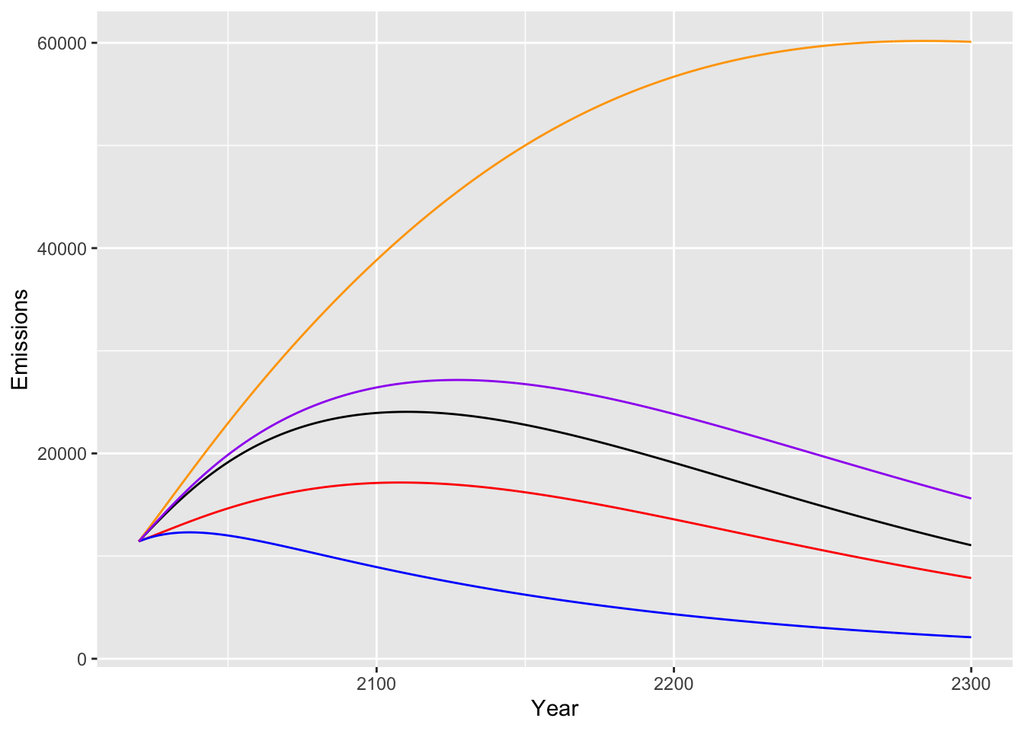

```r
Kaya.global %>%
  ggplot(aes(x = Year)) +
  geom_line(aes(y = Emissions)) +
  geom_line(aes(y = EmissionsPopConstant), color = "red") +
  geom_line(aes(y = EmissionsGDPperCapConstant), color = "blue") +
  geom_line(aes(y = EmissionsEnergyIntensityConstant), color = "orange") +
  geom_line(aes(y = EmissionsEmissionsIntensityConstant), color = "purple")
```

Calculate CO2 concentrations and temperature for emissions paths

```r
Kaya.global <- left_join(Kaya.global, HistoricData, by = c("Year" = "year") )

Box1col <- which(colnames(Kaya.global) == "Box1")

#Implement Five box model for CO2 concentrations
for (i in 2:length(Kaya.global$Year)) {
 Kaya.global[i, Box1col:(Box1col+4)] <- CO2difference(Kaya.global[i - 1, Box1col:(Box1col+4)],
                                                       Kaya.global$Emissions[i - 1])
 }
# Calculate total CO2 concentration in atmosphere
Kaya.global$CO2conc <- Kaya.global$Box1 + Kaya.global$Box2 + Kaya.global$Box3 +
  Kaya.global$Box4 + Kaya.global$Box5
# Calculate radiative forcing
Kaya.global$RF <- RadForc(Kaya.global$CO2conc)
# Calculate Temperatures
for (i in 2:length(Kaya.global$Year)) {
    temp <- Temps(Kaya.global$TempAtm[i-1], Kaya.global$TempOcean[i-1], Kaya.global$RF[i])
  Kaya.global$TempAtm[i] <- temp["atm"]
  Kaya.global$TempOcean[i] <- temp["ocean"]
}
```

Let’s extract the emissions, CO2 concentrations, and atmospheric temperature for the different scenarios and put them in a separate dataframe for convenience.

```r
Exercise13.5 <- Kaya.global %>%
  select(Year, Emissions, CO2conc, TempAtm) %>%
  mutate(ConstantVariable = "None")
```

Now we rerun the Climate model for the other four scenarios and grab the same variables. Start with Population.

```r
#Implement Five box model for CO2 concentrations
for (i in 2:length(Kaya.global$Year)) {
 Kaya.global[i, Box1col:(Box1col+4)] <- CO2difference(Kaya.global[i - 1, Box1col:(Box1col+4)],
                                                       Kaya.global$EmissionsPopConstant[i - 1]) # CHANGE!
 }
# Calculate total CO2 concentration in atmosphere
Kaya.global$CO2conc <- Kaya.global$Box1 + Kaya.global$Box2 + Kaya.global$Box3 +
  Kaya.global$Box4 + Kaya.global$Box5
# Calculate radiative forcing
Kaya.global$RF <- RadForc(Kaya.global$CO2conc)
# Calculate Temperatures
for (i in 2:length(Kaya.global$Year)) {
    temp <- Temps(Kaya.global$TempAtm[i-1], Kaya.global$TempOcean[i-1], Kaya.global$RF[i])
  Kaya.global$TempAtm[i] <- temp["atm"]
  Kaya.global$TempOcean[i] <- temp["ocean"]
}

Exercise13.5 <- Kaya.global %>%
  select(Year, EmissionsPopConstant, CO2conc, TempAtm) %>%
  rename(Emissions = EmissionsPopConstant) %>%
  mutate(ConstantVariable = "Population") %>%
  full_join(Exercise13.5)
```

[output not shown]

Keep Per capita GDP constant

```r
#Implement Five box model for CO2 concentrations
for (i in 2:length(Kaya.global$Year)) {
 Kaya.global[i, Box1col:(Box1col+4)] <- CO2difference(Kaya.global[i - 1, Box1col:(Box1col+4)],
                                                       Kaya.global$EmissionsGDPperCapConstant[i - 1]) # CHANGE!
 }
# Calculate total CO2 concentration in atmosphere
Kaya.global$CO2conc <- Kaya.global$Box1 + Kaya.global$Box2 + Kaya.global$Box3 +
  Kaya.global$Box4 + Kaya.global$Box5
# Calculate radiative forcing
Kaya.global$RF <- RadForc(Kaya.global$CO2conc)
# Calculate Temperatures
for (i in 2:length(Kaya.global$Year)) {
    temp <- Temps(Kaya.global$TempAtm[i-1], Kaya.global$TempOcean[i-1], Kaya.global$RF[i])
  Kaya.global$TempAtm[i] <- temp["atm"]
  Kaya.global$TempOcean[i] <- temp["ocean"]
}

Exercise13.5 <- Kaya.global %>%
  select(Year, EmissionsGDPperCapConstant, CO2conc, TempAtm) %>%
  rename(Emissions = EmissionsGDPperCapConstant) %>%
  mutate(ConstantVariable = "GDPperCapita") %>%
  full_join(Exercise13.5)
```

[output not shown]

Keep Energy Intensity constant

```r
#Implement Five box model for CO2 concentrations
for (i in 2:length(Kaya.global$Year)) {
 Kaya.global[i, Box1col:(Box1col+4)] <- CO2difference(Kaya.global[i - 1, Box1col:(Box1col+4)],
                                                       Kaya.global$EmissionsEnergyIntensityConstant[i - 1]) # CHANGE!
 }
# Calculate total CO2 concentration in atmosphere
Kaya.global$CO2conc <- Kaya.global$Box1 + Kaya.global$Box2 + Kaya.global$Box3 +
  Kaya.global$Box4 + Kaya.global$Box5
# Calculate radiative forcing
Kaya.global$RF <- RadForc(Kaya.global$CO2conc)
# Calculate Temperatures
for (i in 2:length(Kaya.global$Year)) {
    temp <- Temps(Kaya.global$TempAtm[i-1], Kaya.global$TempOcean[i-1], Kaya.global$RF[i])
  Kaya.global$TempAtm[i] <- temp["atm"]
  Kaya.global$TempOcean[i] <- temp["ocean"]
}

Exercise13.5 <- Kaya.global %>%
  select(Year, EmissionsEnergyIntensityConstant, CO2conc, TempAtm) %>%
  rename(Emissions = EmissionsEnergyIntensityConstant) %>%
  mutate(ConstantVariable = "EnergyIntensity") %>%
  full_join(Exercise13.5)
```

[output not shown]

Keep Emissions Intensity constant

```r
#Implement Five box model for CO2 concentrations
for (i in 2:length(Kaya.global$Year)) {
 Kaya.global[i, Box1col:(Box1col+4)] <- CO2difference(Kaya.global[i - 1, Box1col:(Box1col+4)],
                                                       Kaya.global$EmissionsEmissionsIntensityConstant[i - 1]) # CHANGE!
 }
# Calculate total CO2 concentration in atmosphere
Kaya.global$CO2conc <- Kaya.global$Box1 + Kaya.global$Box2 + Kaya.global$Box3 +
  Kaya.global$Box4 + Kaya.global$Box5
# Calculate radiative forcing
Kaya.global$RF <- RadForc(Kaya.global$CO2conc)
# Calculate Temperatures
for (i in 2:length(Kaya.global$Year)) {
    temp <- Temps(Kaya.global$TempAtm[i-1], Kaya.global$TempOcean[i-1], Kaya.global$RF[i])
  Kaya.global$TempAtm[i] <- temp["atm"]
  Kaya.global$TempOcean[i] <- temp["ocean"]
}

Exercise13.5 <- Kaya.global %>%
  select(Year, EmissionsEmissionsIntensityConstant, CO2conc, TempAtm) %>%
  rename(Emissions = EmissionsEmissionsIntensityConstant) %>%
  mutate(ConstantVariable = "EmissionsIntensity") %>%
  full_join(Exercise13.5)
```

[output not shown]

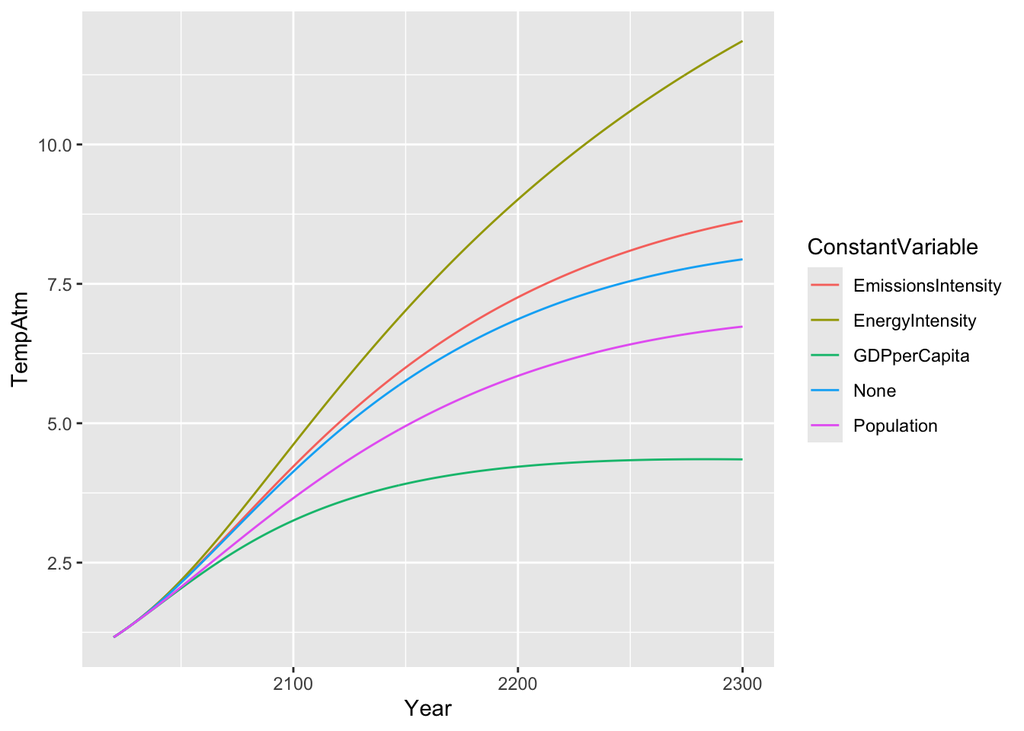

```r
Exercise13.5 %>% ggplot(aes(x = Year, y = TempAtm, color = ConstantVariable)) +
  geom_line()
```

## Using Righ-Middle-Poor Region

Access the regional data

```r
# regional kaya data
regional.df <- read_sheet("https://docs.google.com/spreadsheets/d/1fgR_jtz7zCLynudKfqpjCr2LbORW_tXqHrdGkKFPnDY/edit?gid=0#gid=0")
```

```
## ✔ Reading from "Lab 02 Regional Data".
```

```
## ✔ Range 'Sheet1'.
```

```r
# note the regional data has some issues with the names because the data starts on row 4, with regional labels, etc. in earlier rows
```

```r
Rich.df <- regional.df[-(1:3), c(1, 2, 6, 10, 14)]
Middle.df <- regional.df[-(1:3), c(1, 3, 7, 11, 15)]
names(Middle.df) <- names(Rich.df)
Poor.df <- regional.df[-(1:3), c(1, 4, 8, 12, 16)]
names(Poor.df) <- names(Rich.df)
```